# Final_Project

```python
import pandas as pd
import matplotlib.pyplot as plt
import matplotlib.patches as mpatches
import warnings
import seaborn as sns
```

```python
# Load the dataset
file_path = 'Renewable_Energy_Usage_Sampled.csv'
df = pd.read_csv(file_path)
```

```python
df.head()
```

|  | Household_ID | Region | Country | Energy_Source | Monthly_Usage_kWh | Year | Household_Size | Income_Level | Urban_Rural | Adoption_Year | Subsidy_Received | Cost_Savings_USD |
| --- | --- | --- | --- | --- | --- | --- | --- | --- | --- | --- | --- | --- |
| 0 | H01502 | North America | USA | Hydro | 1043.49 | 2024 | 5 | Low | Urban | 2012 | No | 10.46 |
| 1 | H02587 | Australia | Australia | Geothermal | 610.01 | 2024 | 4 | High | Rural | 2023 | No | 43.49 |
| 2 | H02654 | North America | USA | Biomass | 1196.75 | 2024 | 8 | Low | Rural | 2017 | Yes | 93.28 |
| 3 | H01056 | South America | Colombia | Biomass | 629.67 | 2024 | 7 | High | Urban | 2023 | No | 472.85 |
| 4 | H00706 | Africa | Egypt | Hydro | 274.46 | 2022 | 7 | Middle | Rural | 2010 | No | 65.98 |

```python
df.columns
```

```
Index(['Household_ID', 'Region', 'Country', 'Energy_Source',
       'Monthly_Usage_kWh', 'Year', 'Household_Size', 'Income_Level',
       'Urban_Rural', 'Adoption_Year', 'Subsidy_Received', 'Cost_Savings_USD'],
      dtype='object')
```

```python
# Replace missing values with 'Unknown'
df.fillna('Unknown', inplace=True)
```

```python
# set plot style
sns.set(style="whitegrid")
```

## 1. Bar Chart for Energy Source Distribution

Objective: The goal of this analysis is to examine the distribution of energy sources used by households in the dataset. The objective is to identify which energy sources are more commonly used and to understand their prevalence across the dataset.

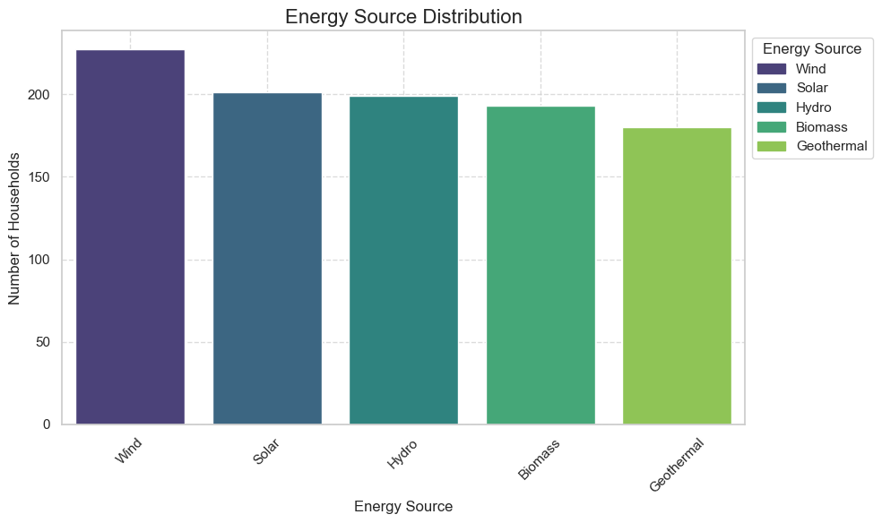

```python
# calculate the count of households for each energy source
energy_source_counts = df['Energy_Source'].value_counts()

# sort the energy source counts in descending order (from most to least)
energy_source_counts = energy_source_counts.sort_values(ascending=False)

# create the bar plot
plt.figure(figsize=(10, 6))
ax = sns.barplot(x=energy_source_counts.index, y=energy_source_counts.values, palette='viridis')

# add proper labels and units
plt.title('Energy Source Distribution', fontsize=16)
plt.xlabel('Energy Source', fontsize=12)
plt.ylabel('Number of Households', fontsize=12)  # Adding units for clarity (Number of Households)
plt.xticks(rotation=45)

# add custom legend with energy source names and their respective colors
colors = ax.patches
labels = energy_source_counts.index

# create custom legend
handles = [mpatches.Patch(color=colors[i].get_facecolor(), label=labels[i]) for i in range(len(labels))]
plt.legend(handles=handles, title="Energy Source", loc="upper left", bbox_to_anchor=(1, 1))

# add gridlines (optional but useful for readability)
plt.grid(True, linestyle='--', alpha=0.7)

# ensure the layout is tight and clean
plt.tight_layout()

# show plot
plt.show()
```

Conclusion : From the data, it's clear that Wind is the most commonly used energy source, with over 200 households relying on it. This shows that wind energy is quite popular, likely because it's widely available and cost-effective in many areas. On the other hand, Geothermal is the least used energy source, with between 150 and 200 households adopting it. While geothermal energy is being used, it’s not as common, possibly due to factors like limited access or higher installation costs. In short, wind energy is leading in popularity, while geothermal energy is used less, but still has some presence.

## 2. FacetGrid with scatter plots: Monthly Usage and Cost Savings by Energy Source

Objective : The objective of this analysis is to investigate the relationship between Monthly Energy Usage (kWh) and Cost Savings (USD) across different Energy Sources such as Hydro, Geothermal, and Biomass. By using visualizations like scatter plots, the analysis aims to provide a clear understanding of how these two variables interact. We will analyze the data by splitting it according to energy source to identify any trends, patterns, or outliers that might suggest certain energy sources lead to greater cost savings based on energy consumption. This will ultimately provide insights that can guide household energy management and inform better decision-making regarding energy usage and savings.

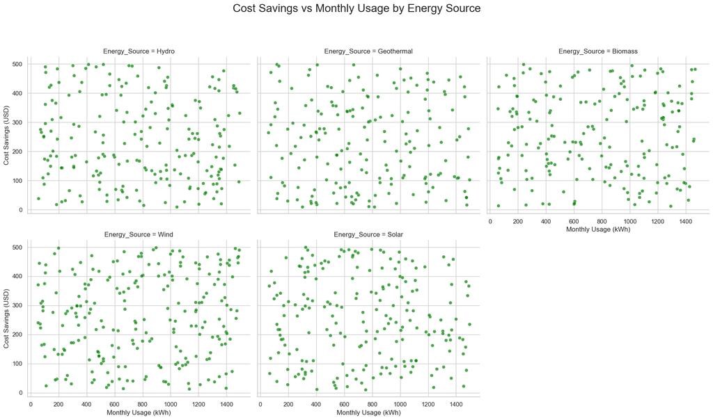

```python
# create a FacetGrid with scatter plots
g = sns.FacetGrid(df, col="Energy_Source", col_wrap=3, height=5, aspect=1.2)

# map a scatter plot to each facet (Monthly Usage vs. Cost Savings)
g.map(sns.scatterplot, "Monthly_Usage_kWh", "Cost_Savings_USD", alpha=0.7, color="green")

# set titles and labels
g.fig.suptitle("Cost Savings vs Monthly Usage by Energy Source", fontsize=20, y=1.05)
g.set_axis_labels("Monthly Usage (kWh)", "Cost Savings (USD)")

# add gridlines to each facet for better readability
for ax in g.axes.flat:
    ax.grid(True)
g.tight_layout()
plt.show()
```

Conclusion : The scatter plot analysis of Cost Savings and Monthly Energy Usage across different Energy Sources reveals important patterns about the relationship between these variables. By faceting the data by energy source, we can identify if higher monthly usage consistently results in higher cost savings for certain energy types, and determine if any anomalies exist. This analysis will help in understanding which energy sources are most effective in terms of cost savings, offering actionable insights for households to optimize their energy usage and achieve better savings. The results may also aid in shaping energy-efficient strategies tailored to specific energy sources, guiding future decisions in household energy consumption.

## 3. Pie Chart : Distribution of Households by Region

Objective: The objective of this analysis is to visualize the distribution of households across different regions in the dataset. By creating a pie chart, we aim to understand the percentage share of each region and explore if certain regions dominate or if the distribution is relatively balanced. This will help in analyzing the geographical spread of energy sources, cost savings, and other related factors.

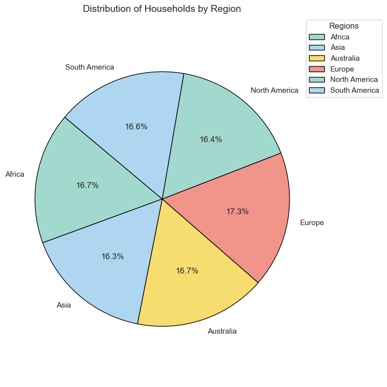

```python
# count the occurrences of each region
region_counts = df['Region'].value_counts().sort_index()  # Sorting the data by Region for consistent order

# create the Pie Chart with light colors
plt.figure(figsize=(8, 8))
colors = ['#A2D9CE', '#AED6F1', '#F7DC6F', '#F1948A']

# pie chart with percentage and sorting
plt.pie(region_counts,
        labels=region_counts.index,
        autopct='%1.1f%%',
        startangle=140,
        colors=colors,
        wedgeprops={'edgecolor': 'black'})

# adding title
plt.title('Distribution of Households by Region', fontsize=14)

# ensure that the pie chart is circular
plt.axis('equal')
plt.legend(region_counts.index, title="Regions", loc="upper left", bbox_to_anchor=(1, 1))
plt.tight_layout()
plt.show()
```

Conclusion : From the pie chart, it is clear that the distribution of households across regions is fairly even. The percentages for each region range between 16.3% and 17.3%, with Europe having the highest share at 17.3%, and Asia having the lowest at 16.3%. This suggests a balanced geographical representation in the dataset, without any single region significantly dominating the data. Such a balanced distribution could be important for further analysis, ensuring that regional differences in energy usage or cost savings are not skewed by an overrepresentation of any particular area.

## 4. Boxplot : Monthly Energy Usage by Region

Objective: The objective of this analysis was to compare monthly energy usage across different regions to identify patterns, variations, and potential outliers in energy consumption.

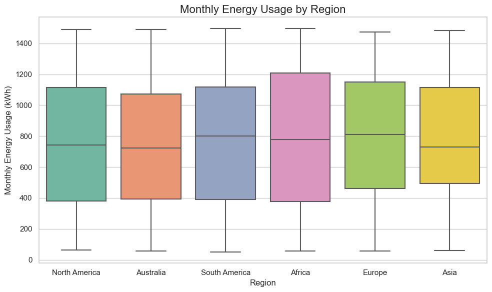

```python
plt.figure(figsize=(10, 6))

# create a boxplot for Monthly Energy Usage by Region
sns.boxplot(x='Region', y='Monthly_Usage_kWh', data=df, palette='Set2')

# adding title and labels
plt.title('Monthly Energy Usage by Region', fontsize=16)
plt.xlabel('Region', fontsize=12)
plt.ylabel('Monthly Energy Usage (kWh)', fontsize=12)
plt.tight_layout()
plt.show()
```

Conclusion : The analysis shows that Europe has the highest typical energy usage, with a median slightly above 800 kWh, followed closely by South America, which has a median just below 800 kWh. Africa's median is lower than South America's but still relatively moderate. North America shows a further decline in median energy usage, placing it below Africa. Asia's median is lower than North America's, and Australia has the lowest median of all regions. This ranking highlights that Europe leads in energy consumption, while Australia has the lowest median among all regions.

## 5. Line Plot : Average Cost Savings Over Time by Urban and Rural Areas

Objective: The objective of the analysis and visualization is to examine the trends in average cost savings (USD) over time across urban and rural areas. By grouping the data by year and urban-rural classification, the goal is to identify patterns or disparities in cost savings between these two classifications.

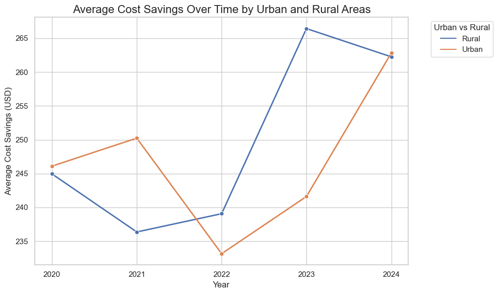

```python
warnings.simplefilter(action='ignore', category=FutureWarning)

df['Year'] = df['Year'].astype(int)

# group the data by 'Year' and 'Urban Rural' and calculate the mean cost savings
avg_cost_savings = df.groupby(['Year', 'Urban_Rural'])['Cost_Savings_USD'].mean().reset_index()

# create a line plot
plt.figure(figsize=(10, 6))
sns.lineplot(data=avg_cost_savings, x='Year', y='Cost_Savings_USD', hue='Urban_Rural', marker='o', linewidth=2)

# set titles and labels
plt.title('Average Cost Savings Over Time by Urban and Rural Areas', fontsize=16)
plt.xlabel('Year', fontsize=12)
plt.ylabel('Average Cost Savings (USD)', fontsize=12)
plt.xticks(ticks=avg_cost_savings['Year'].unique(), labels=[str(int(year)) for year in avg_cost_savings['Year'].unique()])

plt.grid(True)
plt.legend(title="Urban vs Rural", loc="upper left", bbox_to_anchor=(1.05, 1))
plt.subplots_adjust(right=0.8)
plt.tight_layout()
plt.show()
```

Conclusion : The analysis highlights distinct trends in average cost savings across urban and rural areas over the years. In 2020 and 2024, urban and rural areas showed nearly identical savings, reflecting a balance in benefits during these years. However, urban areas outperformed rural areas in 2021, likely due to better policies or efficiencies in urban regions. In contrast, rural areas had higher savings in 2023, which could indicate targeted initiatives or support for rural communities. In 2022, the savings were relatively balanced, with rural areas slightly ahead. These fluctuations suggest that cost savings are influenced by changing policies, economic conditions, or regional initiatives.

## 6. Scatter Plot : Renewable Energy Adoption by Households Over Time

Objective: The goal of this analysis is to explore the trends in the adoption of renewable energy sources over time. We are looking at how many households have adopted different energy sources (such as Biomass, Geothermal, Hydro, Solar, and Wind) each year. This helps us understand which energy sources are becoming more popular and how their adoption has changed over time.

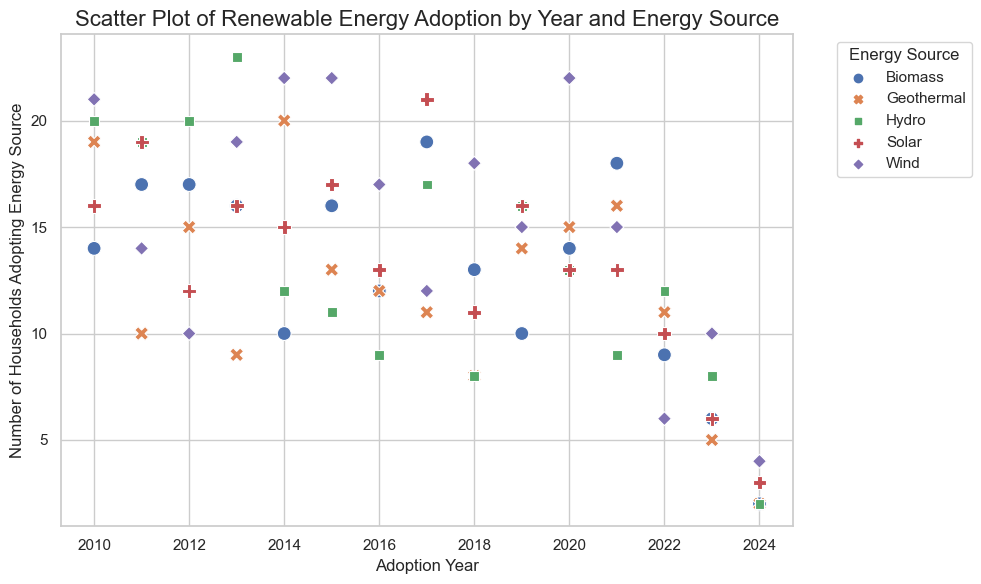

```python
# grouping the data by 'Adoption_Year' and 'Energy_Source' to count the number of households adopting each energy source
early_adoption = df.groupby(['Adoption_Year', 'Energy_Source']).size().reset_index(name='count')

# create a scatter plot to show the adoption trend by energy source
plt.figure(figsize=(10, 6))
sns.scatterplot(data=early_adoption, x='Adoption_Year', y='count', hue='Energy_Source', style='Energy_Source', s=100)

# add titles and labels
plt.title('Scatter Plot of Renewable Energy Adoption by Year and Energy Source', fontsize=16)
plt.xlabel('Adoption Year', fontsize=12)
plt.ylabel('Number of Households Adopting Energy Source', fontsize=12)
plt.grid(True)
plt.legend(title='Energy Source', bbox_to_anchor=(1.05, 1), loc='upper left')
plt.tight_layout()
plt.show()
```